# Differential Expression Tutorial

Mark Dunning; mark ‘dot’ dunning ‘at’ cruk.cam.ac.uk, Oscar Rueda; oscar ‘dot’ rueda ‘at’ cruk.cam.ac.uk

Last modified: 10 Feb 2017

# Importing the data

The data from this experiment comprises nine paired tumor/normal colon tissues on Illumina HT12_v3 gene expression Beadchips. These data were generated to inform a comparison of technologies for microRNA profiling. However, we will only use the mRNA data here.

```r
library(GEOquery)
library(limma)
url <- "ftp://ftp.ncbi.nih.gov/pub/geo/DATA/SeriesMatrix/GSE33126/GSE33126_series_matrix.txt.gz"
filenm <- "data/GSE33126_series_matrix.txt.gz"
if(!file.exists(filenm)) download.file(url, destfile=filenm)
gse <- getGEO(filename=filenm)
```

```
## File stored at:
```

```
## /tmp/RtmpyCVGTI/GPL6947.soft
```

```r
gse
```

```
## ExpressionSet (storageMode: lockedEnvironment)
## assayData: 48803 features, 18 samples
##   element names: exprs
## protocolData: none
## phenoData
##   sampleNames: GSM820516 GSM820517 ... GSM820533 (18 total)
##   varLabels: title geo_accession ... data_row_count (31 total)
##   varMetadata: labelDescription
## featureData
##   featureNames: ILMN_1343291 ILMN_1343295 ... ILMN_2416019 (48803
##     total)
##   fvarLabels: ID nuID ... GB_ACC (30 total)
##   fvarMetadata: Column Description labelDescription
## experimentData: use 'experimentData(object)'
## Annotation: GPL6947
```

```r
head(exprs(gse))
```

```
##               GSM820516  GSM820517  GSM820518  GSM820519  GSM820520
## ILMN_1343291 66665.3800 69404.6700 64128.0700 68943.9700 67827.2200
## ILMN_1343295 22040.1100 13046.3400 38678.9600 16641.8900 33719.8900
## ILMN_1651199   226.6081   205.4483   217.2475   229.0451   226.3029
## ILMN_1651209   278.5710   253.7044   211.8002   278.0423   259.8059
## ILMN_1651210   195.4914   195.9835   175.3356   193.9065   229.5674
## ILMN_1651221   217.2764   206.0723   219.5992   205.0462   194.7481
##               GSM820521  GSM820522  GSM820523  GSM820524  GSM820525
## ILMN_1343291 71775.3000 62245.5900 69713.7000 69509.2700 68244.5900
## ILMN_1343295 18933.2900 26170.0400  9906.9130 17166.5200 12428.9500
## ILMN_1651199   203.8710   213.4431   210.4129   229.5394   212.7384
## ILMN_1651209   265.1900   321.2587   273.4458   253.6032   310.1582
## ILMN_1651210   164.0632   244.6696   190.9813   188.1039   199.3084
## ILMN_1651221   233.9729   233.2414   222.1413   244.1758   209.8247
##               GSM820526  GSM820527  GSM820528  GSM820529  GSM820530
## ILMN_1343291 65427.4700 68436.5200 57608.6700 69959.7700 69509.2700
## ILMN_1343295 25297.5700 17535.6000 19749.1400 17854.2900 43670.6800
## ILMN_1651199   226.1345   232.2437   208.7316   229.2948   214.4033
## ILMN_1651209   275.0126   274.9519   250.6420   255.8540   219.5752
## ILMN_1651210   220.6229   213.3975   194.7746   173.7073   185.3380
## ILMN_1651221   227.8108   255.9940   233.5495   194.4097   218.6604
##               GSM820531  GSM820532  GSM820533
## ILMN_1343291 70063.7700 69647.1700 70332.3400
## ILMN_1343295 22849.0800 23725.6600 28747.0100
## ILMN_1651199   216.6758   195.6539   252.1502
## ILMN_1651209   292.4965   253.3126   237.9844
## ILMN_1651210   174.6898   195.3534   191.9382
## ILMN_1651221   271.4561   222.7748   241.0521
```

## Q Do the data look to be normalised?

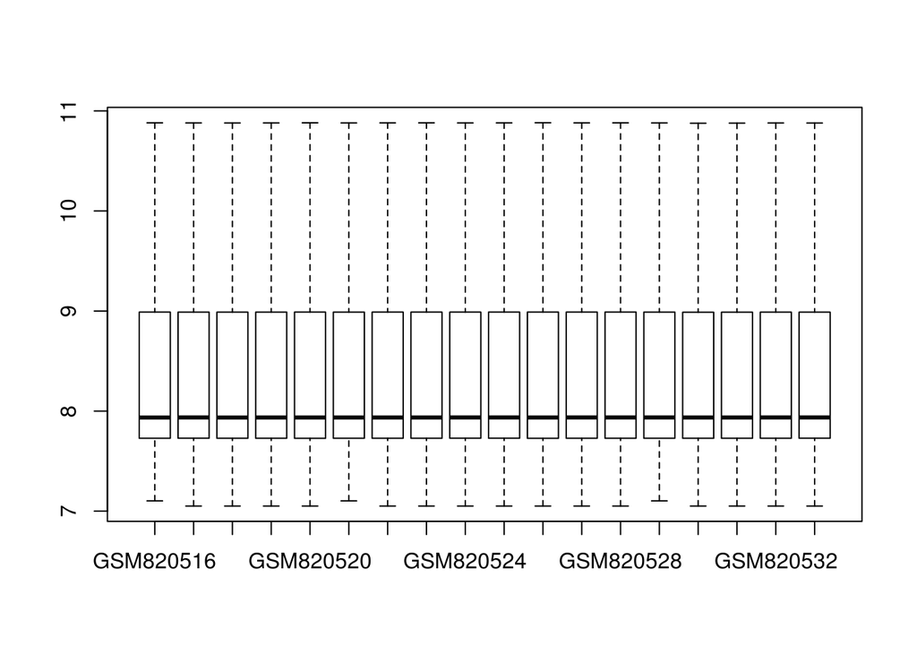

```r
exprs(gse) <- log2(exprs(gse))
boxplot(exprs(gse),outline=FALSE)
```

Inspect the clinical variables

## Q What column has the information about whether is sample is a tumour or normal?

## Q How many do we have in each group?

## Q Create a design matrix for the experiment, on paper if you like

# Simple t-tests

For completeness, we note that t-statistics and corresponding p-values can be generated quickly using the `genefilter` package.

```r
pd <- pData(gse)
SampleGroup <- pd$source_name_ch1
library(genefilter)
destats <- rowttests(exprs(gse),fac=SampleGroup)
head(destats)
```

```
##               statistic          dm     p.value
## ILMN_1343291  2.6776390  0.08354028 0.016510459
## ILMN_1343295 -3.0922257 -0.66722098 0.006992817
## ILMN_1651199  0.5595122  0.02324258 0.583560512
## ILMN_1651209  1.0935577  0.07758592 0.290340309
## ILMN_1651210 -1.5758446 -0.10374687 0.134625663
## ILMN_1651221  0.2322365  0.01441968 0.819298727
```

- Can we remember the drawbacks of this approach?

A useful function is the `model.matrix`, which understands the linear model syntax of R (i.e. using the tilde `~` symbol)

```r
design <- model.matrix(~0+SampleGroup)
colnames(design) <- c("Normal","Tumour")
```

By-hand, we would do;

```r
design <- matrix(nrow=18,ncol=2)
design[,1] <- c(0,1,0,1,0,1,0,1,0,1,0,1,0,1,0,1,0,1)
design[,2] <- c(1,0,1,0,1,0,1,0,1,0,1,0,1,0,1,0,1,0)
colnames(design) <- c("Normal","Tumour")
```

or a shortcut in this would use the `rep` function.

```r
design[,1] <- rep(c(0,1),by=9)
design[,2] <- rep(c(1,0),by=9)
```

Prior to the differential expression analysis, we will *filter* the data so only the top 50% most-variable genes get analysed, which [has been shown](http://www.ncbi.nlm.nih.gov/pmc/articles/PMC2906865/) to increase our power to detect differential expression. We can do this using the `varFilter` function in the `genefilter` package.

```r
library(genefilter)
gse.expFilt <- varFilter(gse)
gse.expFilt
```

```
## ExpressionSet (storageMode: lockedEnvironment)
## assayData: 24401 features, 18 samples
##   element names: exprs
## protocolData: none
## phenoData
##   sampleNames: GSM820516 GSM820517 ... GSM820533 (18 total)
##   varLabels: title geo_accession ... data_row_count (31 total)
##   varMetadata: labelDescription
## featureData
##   featureNames: ILMN_1343295 ILMN_1651228 ... ILMN_2416019 (24401
##     total)
##   fvarLabels: ID nuID ... GB_ACC (30 total)
##   fvarMetadata: Column Description labelDescription
## experimentData: use 'experimentData(object)'
## Annotation: GPL6947
```

The `lmFit` funcion is used to fit the model to the data. The output has various components, most of which you probably don’t need to know about.

```r
fit <- lmFit(exprs(gse.expFilt), design)
names(fit)
```

```
##  [1] "coefficients"     "rank"             "assign"
##  [4] "qr"               "df.residual"      "sigma"
##  [7] "cov.coefficients" "stdev.unscaled"   "pivot"
## [10] "Amean"            "method"           "design"
```

```r
dim(fit$coefficients)
```

```
## [1] 24401     2
```

```r
head(fit$coefficients)
```

```
##                 Normal    Tumour
## ILMN_1343295 14.032346 14.699567
## ILMN_1651228 13.984486 14.329732
## ILMN_1651229  9.661445  9.528996
## ILMN_1651232  8.089572  8.115662
## ILMN_1651237  9.214117 10.153798
## ILMN_1651238  7.710813  7.545338
```

## Q. What is the interpretation of the `coeff` item in the output

Now we define the contrast

```r
contrasts <- makeContrasts(Tumour - Normal, levels=design)
fit2 <- contrasts.fit(fit, contrasts)
head(fit2$coeff)
```

```
##               Contrasts
##                Tumour - Normal
##   ILMN_1343295      0.66722098
##   ILMN_1651228      0.34524651
##   ILMN_1651229     -0.13244960
##   ILMN_1651232      0.02609049
##   ILMN_1651237      0.93968052
##   ILMN_1651238     -0.16547496
```

Finally, apply the *empirical Bayes’* step

```r
fit2 <- eBayes(fit2)
fit2
```

[output not shown]

[output cut: 65 more lines]

```
##  0.004242497  0.013718934  0.477071595  0.783534214  0.007539433
## 24396 more rows ...
##
## $lods
## ILMN_1343295 ILMN_1651228 ILMN_1651229 ILMN_1651232 ILMN_1651237
##    -2.271990    -3.376114    -6.317279    -6.545394    -2.816065
## 24396 more rows ...
##
## $F
## [1] 10.56676330  7.38722816  0.52632548  0.07765668  8.95328702
## 24396 more elements ...
##
## $F.p.value
## [1] 0.004242497 0.013718934 0.477071595 0.783534214 0.007539433
## 24396 more elements ...
```

We usually get our first look at the results by using the `topTable` command

```r
topTable(fit2)
```

```
##                  logFC   AveExpr         t      P.Value    adj.P.Val
## ILMN_1704294  3.269052  9.833508  20.44807 2.544269e-14 6.208271e-10
## ILMN_1813704  4.749574 10.782232  15.96861 2.102340e-12 2.564960e-08
## ILMN_1724686  3.627208 10.814662  15.16574 5.197074e-12 4.227127e-08
## ILMN_1811598 -2.380786  9.150986 -13.41658 4.338822e-11 2.646790e-07
## ILMN_1763749 -5.039637 11.894505 -12.42644 1.599366e-10 7.805228e-07
## ILMN_1652431 -5.998422 11.580616 -11.94769 3.096877e-10 1.259448e-06
## ILMN_1659990  1.259224  8.898440  11.72716 4.228175e-10 1.473881e-06
## ILMN_1702858 -1.511602  9.233874 -11.12718 1.009704e-09 3.079722e-06
## ILMN_1663866  2.038634 14.040020  10.82858 1.577919e-09 4.278090e-06
## ILMN_1657435 -3.354608 10.528543 -10.63195 2.127825e-09 5.111229e-06
##                     B
## ILMN_1704294 21.16212
## ILMN_1813704 17.73053
## ILMN_1724686 16.97912
## ILMN_1811598 15.16284
## ILMN_1763749 14.01219
## ILMN_1652431 13.42051
## ILMN_1659990 13.13976
## ILMN_1702858 12.34868
## ILMN_1663866 11.93958
## ILMN_1657435 11.66437
```

The rows in this table are ordered according the *B-statistic*, or log-odds from the empirical Bayes’ analysis. You should be cautious when interpreting these values. Although a B-statistic of 0 corresponds to a 50/50 chance of a gene being DE, this is contingent on a certain percentage of genes in the experiment being DE. In experiments such as the one we are looked at here, there are a large number of DE genes. In this case genes with B-statistic < 0 could still be DE. Thus, you should use the B-statistic as a ranking criteria and not attempt to compare the values between experiments.

# Including annotation

```r
anno <- fData(gse.expFilt)
head(anno)[,1:5]
```

```
##                        ID               nuID      Species Source
## ILMN_1343295 ILMN_1343295 9fQSYRUddRf4Z6p6T4 Homo sapiens RefSeq
## ILMN_1651228 ILMN_1651228 fZRGweI51.AwJv7v0I Homo sapiens RefSeq
## ILMN_1651229 ILMN_1651229 9EIpq4KI64KL0R57lo Homo sapiens RefSeq
## ILMN_1651232 ILMN_1651232 cqKdrRDdYiRJTTd0aw Homo sapiens RefSeq
## ILMN_1651237 ILMN_1651237 BiXUgqHpd5URfh9LP0 Homo sapiens RefSeq
## ILMN_1651238 ILMN_1651238 WKQZZ4QIE_WAr06inU Homo sapiens RefSeq
##              Search_Key
## ILMN_1343295      GAPDH
## ILMN_1651228   ILMN_992
## ILMN_1651229 ILMN_10123
## ILMN_1651232 ILMN_34533
## ILMN_1651237 ILMN_18895
## ILMN_1651238 ILMN_18299
```

```r
anno <- anno[,c("Symbol","Entrez_Gene_ID","Chromosome","Cytoband")]
fit2$genes <- anno
topTable(fit2)
```

```
##                Symbol Entrez_Gene_ID Chromosome       Cytoband     logFC
## ILMN_1704294     CDH3           1001         16       16q22.1c  3.269052
## ILMN_1813704 KIAA1199          57214         15       15q25.1b  4.749574
## ILMN_1724686    CLDN1           9076          3          3q28c  3.627208
## ILMN_1811598    ADH1B            125          4          4q23b -2.380786
## ILMN_1763749   GUCA2A           2980          1        1p34.2b -5.039637
## ILMN_1652431      CA1            759          8        8q21.2b -5.998422
## ILMN_1659990     HIG2          29923          7        7q32.1a  1.259224
## ILMN_1702858   ADHFE1         137872          8        8q13.1b -1.511602
## ILMN_1663866    TGFBI           7045          5 5q31.1f-q31.2a  2.038634
## ILMN_1657435     MT1M           4499         16         16q13b -3.354608
##                AveExpr         t      P.Value    adj.P.Val        B
## ILMN_1704294  9.833508  20.44807 2.544269e-14 6.208271e-10 21.16212
## ILMN_1813704 10.782232  15.96861 2.102340e-12 2.564960e-08 17.73053
## ILMN_1724686 10.814662  15.16574 5.197074e-12 4.227127e-08 16.97912
## ILMN_1811598  9.150986 -13.41658 4.338822e-11 2.646790e-07 15.16284
## ILMN_1763749 11.894505 -12.42644 1.599366e-10 7.805228e-07 14.01219
## ILMN_1652431 11.580616 -11.94769 3.096877e-10 1.259448e-06 13.42051
## ILMN_1659990  8.898440  11.72716 4.228175e-10 1.473881e-06 13.13976
## ILMN_1702858  9.233874 -11.12718 1.009704e-09 3.079722e-06 12.34868
## ILMN_1663866 14.040020  10.82858 1.577919e-09 4.278090e-06 11.93958
## ILMN_1657435 10.528543 -10.63195 2.127825e-09 5.111229e-06 11.66437
```

# Diagnostic checks

At this point it is useful to take stock and do some diagnostic checks

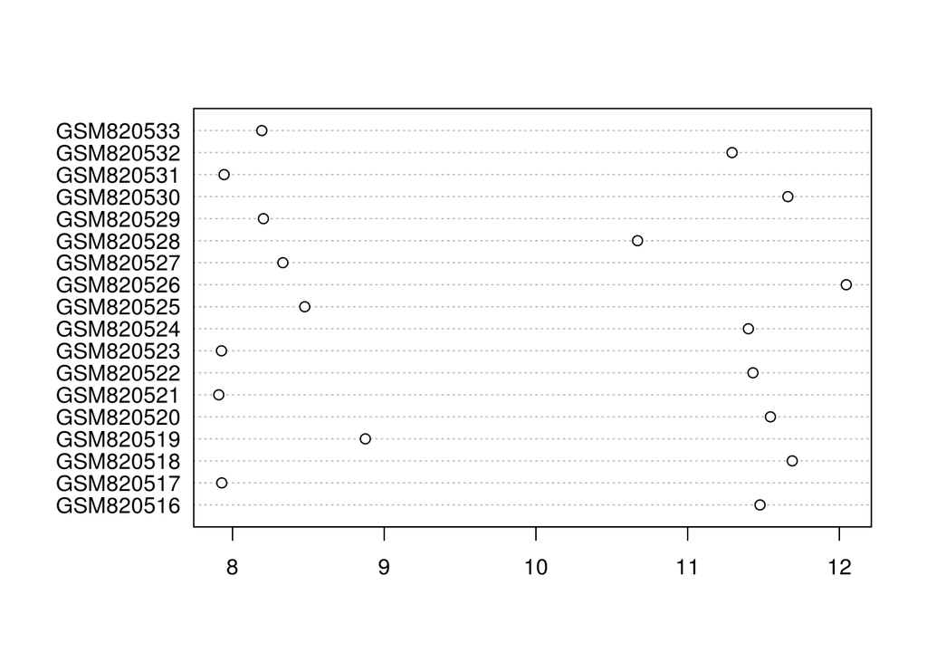

```r
dotchart(exprs(gse)["ILMN_1704294",])
```

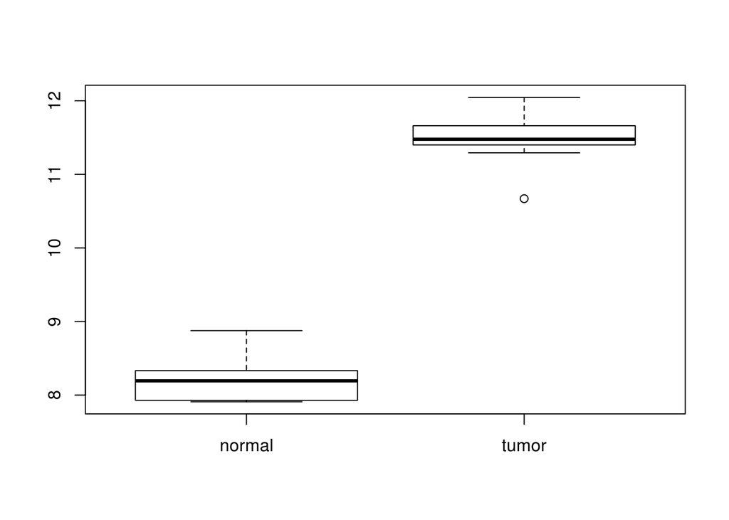

```r
boxplot(exprs(gse)["ILMN_1704294",]~SampleGroup)
```

To find how many genes are DE we can use the `decideTests` function, which also applies multiple-test correction.

*Make a note of how many genes are DE, you will need this later*

```r
decideTests(fit2)
```

```
## TestResults matrix
## ILMN_1343295 ILMN_1651228 ILMN_1651229 ILMN_1651232 ILMN_1651237
##            1            0            0            0            0
## 24396 more rows ...
```

```r
table(decideTests(fit2))
```

```
##
##    -1     0     1
##  1438 21057  1906
```

```r
sum(abs(decideTests(fit2))==1)
```

```
## [1] 3344
```

The “*Volcano Plot*” function is a common way of visualising the results of a DE analysis. The $x$ axis shows the log-fold change and the $y$ axis is some measure of statistical significance, which in this case is the log-odds, or “B” statistic. A characteristic “volcano” shape should be seen.

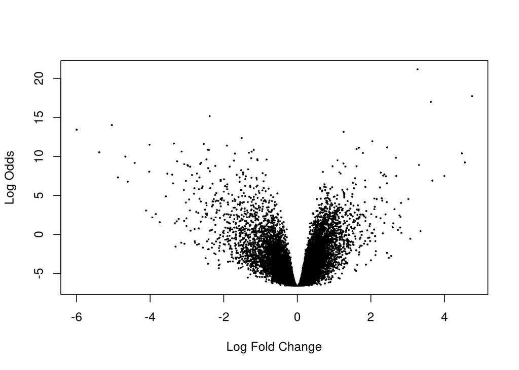

```r
volcanoplot(fit2)
```

The function also has options to highlight the postions of the top N genes from the test.

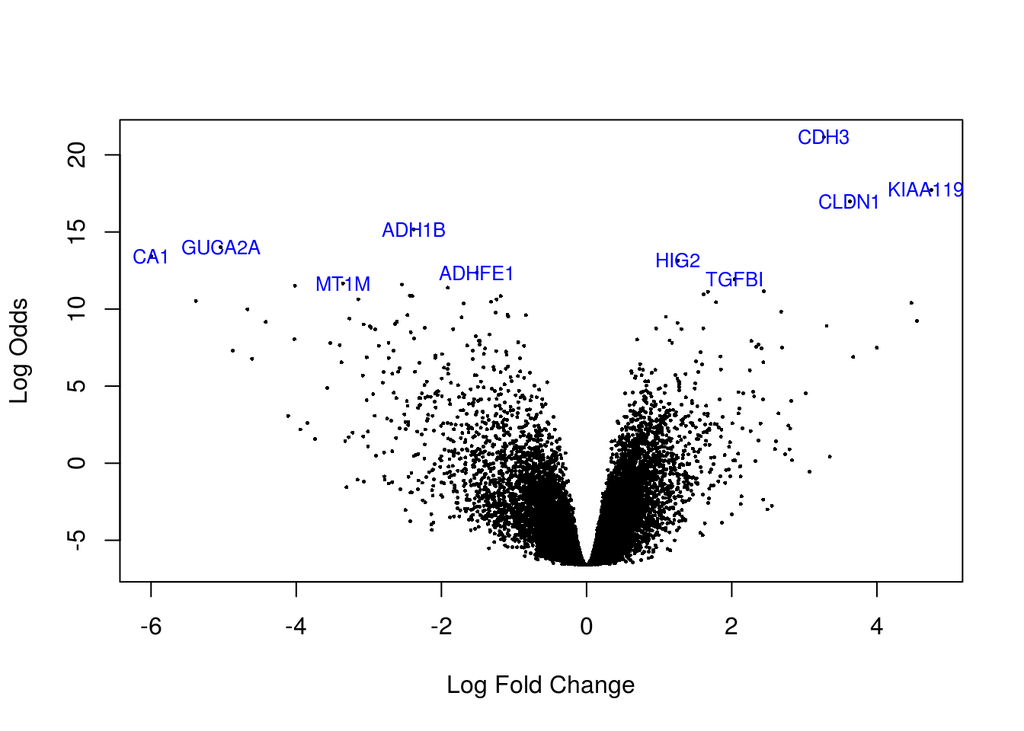

```r
volcanoplot(fit2,highlight=10,names = fit2$genes$"Symbol")
```

# Exporting the results

```r
write.fit(fit2, file = "de-results.txt",adjust="BH")
```

# Getting the results for a particular gene

The `topTable` function by default only prints the top 10 DE genes. However, by changing the arguments we can make it print the statistics for all the genes that we test.

```r
testResults <- topTable(fit2, number=nrow(fit2))
```

This gives us the opportunity to look-up the results for particular genes of interest. Lets say we’re interested in “OCIAD2” (for no particular reason…)

```r
testResults[which(testResults$Symbol == "OCIAD2"),]
```

```
##              Symbol Entrez_Gene_ID Chromosome Cytoband     logFC  AveExpr
## ILMN_1700306 OCIAD2         132299          4    4p12a 0.7480189 13.40736
## ILMN_1772286 OCIAD2         132299          4    4p12a 0.7877357 10.92200
##                     t      P.Value   adj.P.Val          B
## ILMN_1700306 4.190794 0.0005035995 0.009607765 -0.2227105
## ILMN_1772286 3.538375 0.0022183900 0.024230499 -1.6530080
```

If we have a list of genes, the `%in%` function can be used.

```r
mylist <- c("LOC441066","ARF3","FMNL3","CSF1R","XLKD1","TTRAP","DMWD","SYNPO2L","PILRB","LAMP3")

testResults[which(testResults$Symbol %in% mylist),]
```

```
##                 Symbol Entrez_Gene_ID Chromosome  Cytoband       logFC
## ILMN_2210753     XLKD1          10894         11  11p15.4a -1.45372426
## ILMN_1785821     TTRAP          51567          6   6p22.2b -0.43214642
## ILMN_1768754     PILRB          29990          7   7q22.1c -0.37606793
## ILMN_1686623     CSF1R           1436          5   5q33.1c -0.39403423
## ILMN_2183216     TTRAP          51567          6   6p22.2b -0.34506377
## ILMN_1657955     FMNL3          91010         12 12q13.12c  0.10533704
## ILMN_1685534     PILRB          29990          7   7q22.1c  0.07702480
## ILMN_1690253   SYNPO2L          79933         10  10q22.2a  0.06322535
## ILMN_1807712     PILRB          29990          7   7q22.1c  0.08345081
## ILMN_1682938      ARF3            377         12 12q13.12a -0.07912146
## ILMN_1714352      DMWD           1762         19 19q13.32a  0.11488061
## ILMN_2170813     LAMP3          27074          3   3q27.1a  0.04895846
## ILMN_1714808 LOC441066         441066          5   5q21.1b  0.04097845
## ILMN_1723984     PILRB          29990          7   7q22.1c  0.04075150
## ILMN_2395214     FMNL3          91010         12 12q13.12c  0.02334380
## ILMN_2170814     LAMP3          27074          3   3q27.1a -0.02860983
##                AveExpr           t      P.Value    adj.P.Val         B
## ILMN_2210753  8.469606 -6.23603683 5.672890e-06 0.0006207362  4.147419
## ILMN_1785821  8.700032 -1.88536236 7.489913e-02 0.2298027154 -4.905780
## ILMN_1768754 11.081650 -1.35504089 1.914305e-01 0.4149090657 -5.680934
## ILMN_1686623 11.593908 -1.25905686 2.233870e-01 0.4549592337 -5.799590
## ILMN_2183216  9.003461 -1.21319562 2.400473e-01 0.4741293394 -5.853696
## ILMN_1657955  8.010168  1.02756048 3.171695e-01 0.5584683031 -6.054871
## ILMN_1685534  8.116290  0.76377698 4.544597e-01 0.6807561543 -6.288670
## ILMN_1690253  7.719182  0.74547643 4.651835e-01 0.6894119309 -6.302515
## ILMN_1807712  8.638967  0.55453559 5.857359e-01 0.7787153453 -6.427850
## ILMN_1682938 11.506627 -0.48960363 6.300665e-01 0.8077682634 -6.462371
## ILMN_1714352  9.153734  0.43380919 6.693539e-01 0.8312757025 -6.488688
## ILMN_2170813  8.521685  0.33382435 7.421991e-01 0.8744761426 -6.528028
## ILMN_1714808  8.273997  0.25762280 7.994910e-01 0.9070871664 -6.551204
## ILMN_1723984  7.887657  0.23765047 8.147175e-01 0.9141899453 -6.556298
## ILMN_2395214  8.693602  0.12395878 9.026609e-01 0.9591042109 -6.577500
## ILMN_2170814  9.633219 -0.07762576 9.389442e-01 0.9745572234 -6.582323
```

# Further filtering and ordering

- Q. Create a data frame containing genes with i) adjusted p-value < 0.05 ii) log-fold change > 1. How many genes does this contain?
- Q. Now order this data frame according to chromosome

# Improved analysis: Doing a paired analysis

- Q. What would the design matrix look like to incorporate patient ID into the model
- Q. Create this model using the `model.matrix` function
- Q. Proceed to fit your model to the data
- Q. How many genes are DE? How does this compare to the previous model?

```r
## Your answer here ##
```

# The estrogen dataset

Recall the estrogen dataset from yesterday

```r
library(affy)
targetsFile <- "estrogen/estrogen.txt"
pd <- read.AnnotatedDataFrame(targetsFile,header=TRUE,sep="",row.names=1)
pData(pd)
```

```
##              estrogen time.h
## low10-1.cel    absent     10
## low10-2.cel    absent     10
## high10-1.cel  present     10
## high10-2.cel  present     10
## low48-1.cel    absent     48
## low48-2.cel    absent     48
## high48-1.cel  present     48
## high48-2.cel  present     48
```

```r
ER <- pData(pd)$estrogen
Time <- factor(pData(pd)$time.h)
design <- model.matrix(~ER+Time)
design
```

```
##   (Intercept) ERpresent Time48
## 1           1         0      0
## 2           1         0      0
## 3           1         1      0
## 4           1         1      0
## 5           1         0      1
## 6           1         0      1
## 7           1         1      1
## 8           1         1      1
## attr(,"assign")
## [1] 0 1 2
## attr(,"contrasts")
## attr(,"contrasts")$ER
## [1] "contr.treatment"
##
## attr(,"contrasts")$Time
## [1] "contr.treatment"
```

```r
design2 <- model.matrix(~ER*Time)
design2
```

```
##   (Intercept) ERpresent Time48 ERpresent:Time48
## 1           1         0      0                0
## 2           1         0      0                0
## 3           1         1      0                0
## 4           1         1      0                0
## 5           1         0      1                0
## 6           1         0      1                0
## 7           1         1      1                1
## 8           1         1      1                1
## attr(,"assign")
## [1] 0 1 2 3
## attr(,"contrasts")
## attr(,"contrasts")$ER
## [1] "contr.treatment"
##
## attr(,"contrasts")$Time
## [1] "contr.treatment"
```

# Reading and normalising the data

We read the data and then apply rma normalisation. What are the steps?

```r
raw <-ReadAffy(celfile.path = "estrogen", filenames=rownames(pData(pd)),phenoData = pd)
raw
```

```
## AffyBatch object
## size of arrays=640x640 features (19 kb)
## cdf=HG_U95Av2 (12625 affyids)
## number of samples=8
## number of genes=12625
## annotation=hgu95av2
## notes=
```

```r
eset <- rma(raw)
```

```
## Background correcting
## Normalizing
## Calculating Expression
```

```r
eset
```

```
## ExpressionSet (storageMode: lockedEnvironment)
## assayData: 12625 features, 8 samples
##   element names: exprs
## protocolData
##   sampleNames: low10-1.cel low10-2.cel ... high48-2.cel (8 total)
##   varLabels: ScanDate
##   varMetadata: labelDescription
## phenoData
##   sampleNames: low10-1.cel low10-2.cel ... high48-2.cel (8 total)
##   varLabels: estrogen time.h
##   varMetadata: labelDescription
## featureData: none
## experimentData: use 'experimentData(object)'
## Annotation: hgu95av2
```

# Fitting the models

Fit the model with and without interaction.

```r
library(limma)
fit1 <- lmFit(eset, design)
fit1 <- eBayes(fit1)
topTable(fit1, coef=2)
```

```
##              logFC   AveExpr        t      P.Value    adj.P.Val         B
## 910_at    3.484397  9.660238 23.45683 9.857528e-10 4.856645e-06 12.293257
## 41400_at  2.312275 10.041553 23.18878 1.097642e-09 4.856645e-06 12.214778
## 39755_at  1.722290 12.131839 23.06484 1.154054e-09 4.856645e-06 12.177991
## 40117_at  2.415755  9.676557 20.61439 3.292172e-09 1.039092e-05 11.379761
## 31798_at  3.198764 12.115778 18.59763 8.570374e-09 1.848386e-05 10.605992
## 1824_s_at 1.778002  9.238870 18.54821 8.784407e-09 1.848386e-05 10.585509
## 36134_at  2.466614  8.275734 17.51134 1.496103e-08 2.698329e-05 10.137159
## 1884_s_at 2.693047  9.034796 16.99701 1.970251e-08 3.084438e-05  9.900860
## 1854_at   2.924256  8.532099 16.79596 2.198807e-08 3.084438e-05  9.805830
## 673_at    1.476417  9.828894 15.24039 5.372461e-08 6.630068e-05  9.015793
```

```r
fit2 <- lmFit(eset, design2)
fit2 <- eBayes(fit2)
topTable(fit2, coef=2)
```

```
##              logFC   AveExpr        t      P.Value    adj.P.Val        B
## 39642_at  2.939428  7.876515 23.71715 4.741579e-09 3.128295e-05 9.966810
## 910_at    3.113733  9.660238 23.59225 4.955715e-09 3.128295e-05 9.942522
## 31798_at  2.800195 12.115778 16.38509 1.025747e-07 3.511070e-04 7.977290
## 41400_at  2.381040 10.041553 16.22463 1.112418e-07 3.511070e-04 7.916921
## 40117_at  2.555282  9.676557 15.68070 1.472942e-07 3.576234e-04 7.705093
## 1854_at   2.507616  8.532099 15.15848 1.945518e-07 3.576234e-04 7.490766
## 39755_at  1.679331 12.131839 15.06365 2.048314e-07 3.576234e-04 7.450643
## 1824_s_at 1.914637  9.238870 14.87915 2.266129e-07 3.576234e-04 7.371475
## 1126_s_at 1.782825  6.879918 13.83040 4.119252e-07 5.778395e-04 6.892307
## 1536_at   2.662258  5.937222 13.26247 5.795111e-07 7.316327e-04 6.610486
```

## Q. Which one do you prefer? Why?

[output not shown]